# Lab: Exploratory Data Analysis

36-600

In today’s lab, you were perform exploratory data analysis on a dataset related to heart disease and the cost billed to insurance.

# Data

Your first job is to retrieve the dataset, `heart_disease.csv`, from the course `Canvas` site. You will find a link this dataset on the lab module page.

Examine the downloaded data file. Think about how you would input these data (hint: do any strings represent factor variables? do you need to specify column types? etc.). Then…

# Questions

## Question 1

Input the data into `R`, and into a data frame named `df`.

```r
df<-read.csv('heart_disease.csv')
```

## Question 2

Summarize the data, via a base-`R` function mentioned in today’s notes. Scan the output to see if there are missing data or if anything appears weird.

```r
summary(df)
```

```
##       Cost              Age           Gender          Interventions
##  Min.   :    0.0   Min.   :24.00   Length:788         Min.   : 0.000
##  1st Qu.:  161.1   1st Qu.:55.00   Class :character   1st Qu.: 1.000
##  Median :  507.2   Median :60.00   Mode  :character   Median : 3.000
##  Mean   : 2800.0   Mean   :58.72                      Mean   : 4.707
##  3rd Qu.: 1905.5   3rd Qu.:64.00                      3rd Qu.: 6.000
##  Max.   :52664.9   Max.   :70.00                      Max.   :47.000
##      Drugs           ERVisit       Complications     Comorbidities
##  Min.   :0.0000   Min.   : 0.000   Min.   :0.00000   Min.   : 0.000
##  1st Qu.:0.0000   1st Qu.: 2.000   1st Qu.:0.00000   1st Qu.: 0.000
##  Median :0.0000   Median : 3.000   Median :0.00000   Median : 1.000
##  Mean   :0.3388   Mean   : 3.425   Mean   :0.05457   Mean   : 3.767
##  3rd Qu.:0.0000   3rd Qu.: 5.000   3rd Qu.:0.00000   3rd Qu.: 5.000
##  Max.   :2.0000   Max.   :20.000   Max.   :1.00000   Max.   :60.000
##     Duration            id
##  Min.   :  0.00   Min.   :  1.0
##  1st Qu.: 41.75   1st Qu.:197.8
##  Median :165.50   Median :394.5
##  Mean   :164.03   Mean   :394.5
##  3rd Qu.:281.00   3rd Qu.:591.2
##  Max.   :372.00   Max.   :788.0
```

## Question 3

One thing you might have noticed in Question 2 is that `Drugs` apparently can only take on the values 0, 1, and 2, and that `Complications` is either 0 or 1. This hints that these are actually factor variables, and not numeric. For purposes of visualization and analysis, it can be helpful to forcibly transform these variables from being of `numeric` type to being of `factor` type. You would do that as follows:

```
df$Drugs <- factor(df$Drugs)
```

Convert both variables, and re-display the summary.

```r
df$Drugs <- factor(df$Drugs)
df$Complications <- factor(df$Complications)
df$Gender <- factor(df$Gender)
summary(df)
```

```
##       Cost              Age           Gender    Interventions    Drugs
##  Min.   :    0.0   Min.   :24.00   Female:608   Min.   : 0.000   0:610
##  1st Qu.:  161.1   1st Qu.:55.00   Male  :180   1st Qu.: 1.000   1: 89
##  Median :  507.2   Median :60.00                Median : 3.000   2: 89
##  Mean   : 2800.0   Mean   :58.72                Mean   : 4.707
##  3rd Qu.: 1905.5   3rd Qu.:64.00                3rd Qu.: 6.000
##  Max.   :52664.9   Max.   :70.00                Max.   :47.000
##     ERVisit       Complications Comorbidities       Duration
##  Min.   : 0.000   0:745         Min.   : 0.000   Min.   :  0.00
##  1st Qu.: 2.000   1: 43         1st Qu.: 0.000   1st Qu.: 41.75
##  Median : 3.000                 Median : 1.000   Median :165.50
##  Mean   : 3.425                 Mean   : 3.767   Mean   :164.03
##  3rd Qu.: 5.000                 3rd Qu.: 5.000   3rd Qu.:281.00
##  Max.   :20.000                 Max.   :60.000   Max.   :372.00
##        id
##  Min.   :  1.0
##  1st Qu.:197.8
##  Median :394.5
##  Mean   :394.5
##  3rd Qu.:591.2
##  Max.   :788.0
```

## Question 4

Look at your summary output again. Are there any obviously non-informative columns? If so, remove them here. For instance, use `dplyr` functions to remove the offending column(s), and save the output to `df`. Note: to remove a single column, you can name it and put a minus sign in front. Then show the names of the columns of `df` so you can convince yourself that the offending column(s) are gone.

```r
suppressMessages(library(tidyverse))
df<-df %>% mutate(id=NULL)
names(df)
```

```
## [1] "Cost"          "Age"           "Gender"        "Interventions"
## [5] "Drugs"         "ERVisit"       "Complications" "Comorbidities"
## [9] "Duration"
```

When performing exploratory data analysis and reporting the results to others, it can be quite helpful to employ “faceting” to save space. (It makes the plots smaller, but it also makes them easier to compare against each other.)

In Question 5 below, you will create faceted plots for all the truly quantitative variables (meaning, everything but `Gender`, `Drugs`, and `Complications`). The typical approach is to utilize histograms. But, how do you create the plots?

First, you have to `select()` the columns of data you wish to visualize (while selecting either “positively” or “negatively”…whichever leads to less typing!), to pass the selected columns to the `gather()` function, and save the output from `gather()` (say, as `df.quant`).

What `gather()` does is output a data frame whose first column, `key`, is a factor variable with column names, and whose second column, `value`, contains the variable values. For instance, it turns`

```
a   b   c
1   2   3
4   5   6
```

into

```
key   value
a     1
a     4
b     2
b     5
c     3
c     6
```

The next step would be to take the output from `gather()` (saved here as `df.quant`) and simply histogram it, in the manner we do in the lecture notes…but we need to add one additional line:

```
  ... +
  geom_histogram(col="burlywood") +  # or whatever color and bin size, etc.
  facet_wrap(~key,scales='free_x')
```

About the `scales` argument: `free_x` means “let the plot limits along the $x$-axis differ in each histogram but keep the $y$-axis limits fixed,” `free_y` means the opposite, and `free` means “let the plot limits along each axis differ.” Play with this to see which allows for the best pictorial representation of the distributions of variable values.

## Question 5

Create a faceted histogram for all the variables that are truly quantitative, meaning leave `Gender`, `Drugs`, and `Complications` out. Try `scales="free_x"` and `scales="free"` and keep the one that leads to “better” results. (Note that when constructing the histograms, the `x` variable in the call to `aes()` is `value`.)

```r
field<-setdiff(names(df), c("Gender", "Drugs", "Complications"))
df.quant <- gather(select(df, field))
```

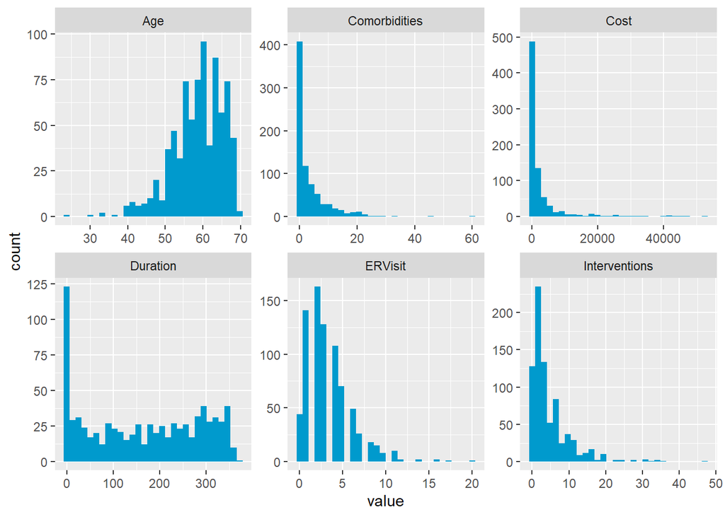

```r
ggplot(data=df.quant,mapping=aes(x=value)) +
  geom_histogram(fill="deepskyblue3",bins=30) +
  facet_wrap(~key,scales='free')
```

## Question 6

Look at `Cost`: it is right skew. Make a histogram of the base-10 logarithm of `Cost`, i.e., do

```
hist(log10(df$Cost),col="blue")   # quick'n'dirty, no ggplot needed here!
```

Does this look more symmetric? If yes, replace the `Cost` column, i.e., do

```
df %>% filter(.,Cost>0) -> df
df$Cost = log10(df$Cost)
```

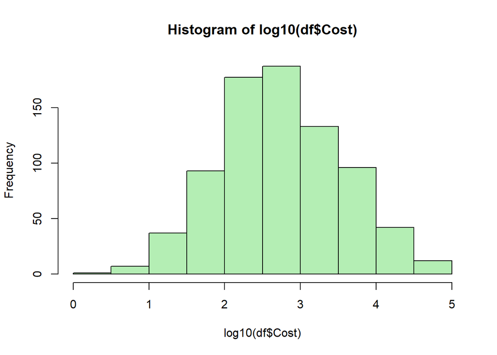

```r
hist(log10(df$Cost),col="darkseagreen2")
```

```r
df %>% filter(.,Cost>0) -> df
df$Cost = log10(df$Cost)
```

## Question 7

Create base-`R` tables and `ggplot`-style bar charts for `Gender`, `Drugs`, and `Complications`. Employ faceting for the bar charts! (See the lecture notes for guidance on how to create bar charts, while noting that like above, the `x` value in the call to `aes()` is `value`.)

(Ignore any warnings about “attributes are not identical…”)

```r
gdc<-setdiff(names(df), field)
df.gdc <- gather(select(df, gdc))
```

[output not shown]

```
## Warning: attributes are not identical across measure variables; they will be
## dropped
```

```r
df.gdc %>% select(key,value) %>% table(.)
```

```
##                value
## key               0   1   2 Female Male
##   Complications 742  43   0      0    0
##   Drugs         608  88  89      0    0
##   Gender          0   0   0    608  177
```

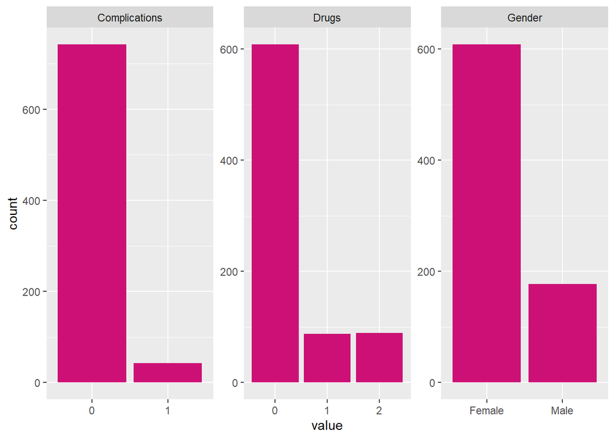

```r
ggplot(data=df.gdc,mapping=aes(x=value)) +
  geom_bar(fill="deeppink3",bins=30) +
  facet_wrap(~key,scales='free')
```

## Question 8

Let’s visualize `Drugs` and `Complications` at the same time. One way to do this is via a two-way table: simply pass both variable names to `table()` and see what happens. Such visualization can also be done in `ggplot` but it is considerably more complicated a task than we wish to tackle here.

```r
table(df$Drugs, df$Complications)
```

```
##
##       0   1
##   0 580  28
##   1  81   7
##   2  81   8
```

## Question 9

Let’s assume that `Cost` is our response variable: ultimately we want to learn regression models that predict `Cost` given the values of the remaining (predictor) variables. (We’ll actually carry this out later!) What we might want to do now is see how `Cost` varies as a function of other variables.

First job: create side-by-side boxplots for `Cost` vs. `Gender`, `Cost` vs. `Drugs`, and `Cost` vs. `Complications`. As you might guess, we can do this via faceting, but it is a little more complicated. Just a little. Above, in the calls to `aes()`, the argument was `x=value`. Now that we have another variable, we need to add another argument: use `y=rep(df$Cost,3)`. This repeats the response vector three times, one time for each of the categorical predictors.

To make the $y$-axis label look better, add on the following after `facet_wrap()`: `+ ylab("Log Cost")`.

Do any of the categorical variables appear to be associated with the values of the response variable? (No need to write down an answer…just look and come to a conclusion.)

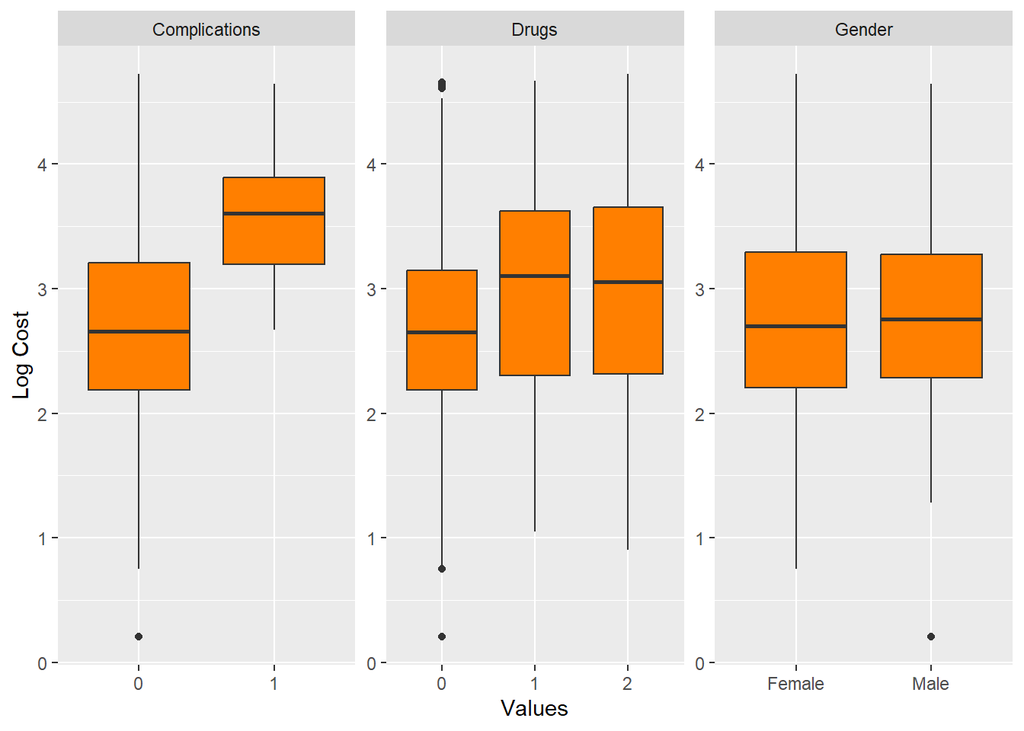

```r
ggplot(data=df.gdc,mapping=aes(x=value,y=rep(df$Cost,3))) +
  geom_boxplot(fill="darkorange1") +
  xlab("Values") + ylab("Log Cost")+
  facet_wrap(~key,scales='free')
```

## Question 10

Your next job: show scatter plots of `Cost` ($y$-axis) versus all the remaining predictor variables. As far as faceting…do what you did in Question 9, but replace `geom_boxplot()` with `geom_point()`.

Note: when doing `select()`, make sure to take `Cost` out! We don’t need to plot `Cost` vs. `Cost` here. Also, there are five quantitative predictor variables.

Which quantiative predictors appear to be associated with the response variable? (Again, answer this to yourself, mentally.)

```r
q<-setdiff(field, "Cost")
df.quant<-gather(select(df, q))
```

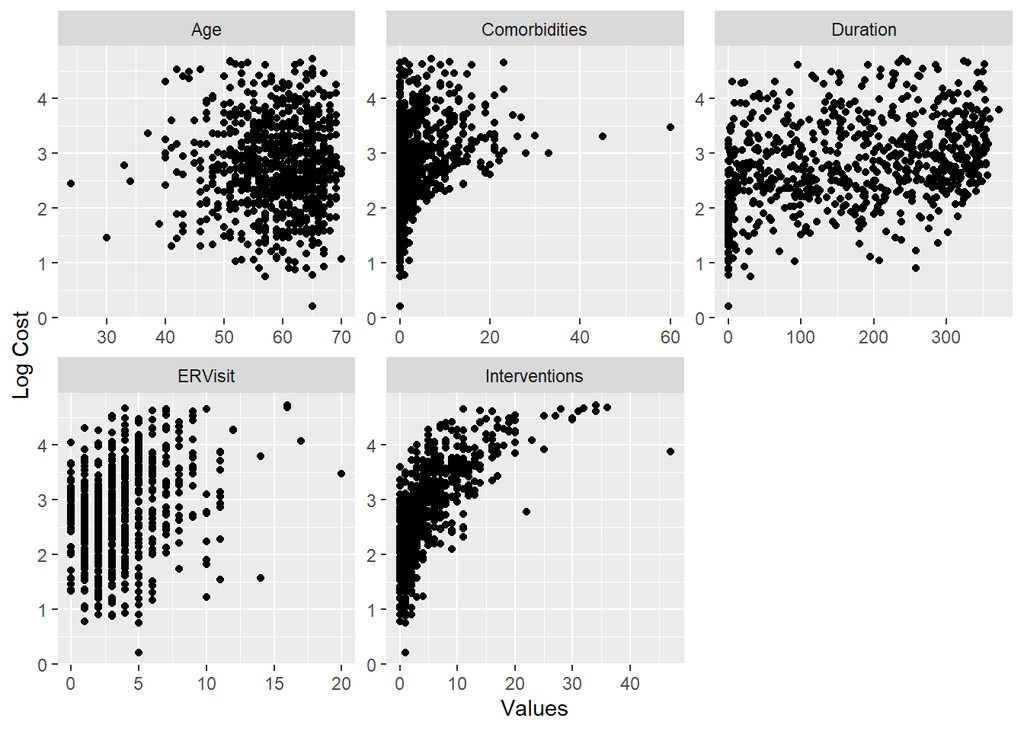

```r
ggplot(data=df.quant,mapping=aes(x=value,y=rep(df$Cost, length(q)))) +
  geom_point() +
  xlab("Values") + ylab("Log Cost")+
  facet_wrap(~key,scales='free')
```

## Question 11

And your last job: visually determine the level of correlation (i.e., level of linear dependence) between all the quantitative predictor variables. We didn’t talk about this in lecture, so…

First, install the package `corrplot`. Once that is done, uncomment the line `suppressMessages(library(corrplot))` below.

Then, select the quantitative predictors (again, don’t select `Cost`!) and pass the output from `select()` into `cor()` (no arguments, save the “.”), and pass the output from `cor()` into `corrplot()` (first argument “.”, and second argument `method="<something>"`…look at the documentation for choices…my preferred `"<something>"` is “ellipse”).

Why might apparent associations between predictor variables be bad, if you see any? We’ll talk about this at length in a later lecture, but in short it would be evidence of *multicollinearity*, which can affect your ability to interpret any models that you learn (particularly linear regression models).

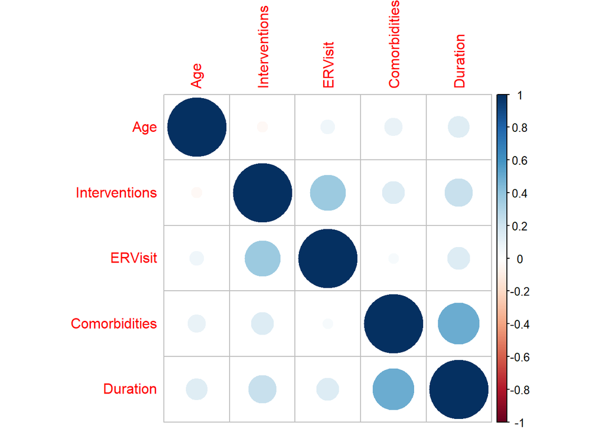

```r
suppressMessages(library(corrplot))
correl<-cor(select(df, q))
corrplot(correl)
```